# 21110027_Sausan_P12

Sausan

2024-01-08

# Library

```r
library(readxl) #untuk membaca file excel
library(plotrix) #untuk membentuk pie chart
library(car) #untuk menghitung VIF masing2 prediktor
```

# Memanggil data dan membuat dataframe

```r
data <- read_excel("C:/Users/LENOVO/Documents/Analisis Prediktif/PRAK/survey lung cancer dataset praktikum.xlsx")
View(data)
```

```r
X1 = as.factor(data$GENDER)
X2 = data$AGE
X3 = as.factor(data$SMOKING)
X4 = as.factor(data$ALCOHOL_CONSUMING)
X5 = as.factor(data$COUGHING)
X6 = as.factor(data$SWALLOWING_DIFFICULTY)
X7 = as.factor(data$CHEST_PAIN)
Y = as.factor(data$LUNG_CANCER)
df = data.frame(X1, X2, X3, X4, X5, X6, X7, Y)
```

# Pie Chart Proporsi Pasien

```r
CANCER = table(df$Y)
CANCER
```

```
##
##  NO YES
##  39 270
```

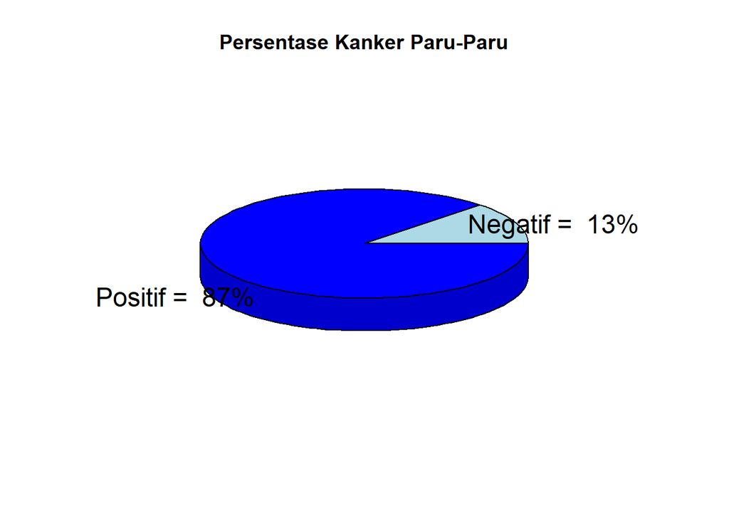

```r
kat = c("Negatif = ","Positif = ")
persentase = round(CANCER/sum(CANCER)*100)
kat = paste(kat,persentase)
kat = paste(kat,'%',sep='')
pie3D(CANCER, labels = kat, col = c('light blue', 'blue'),
      main = "Persentase Kanker Paru-Paru")
```

Dari diagram pie, 87% pasien diperkirakan positif terhadap kanker paru-paru, sementara 13% diperkirakan negatif.

# Histogram Hasil Tes Kanker Berdasarkan Jenis Kelamin

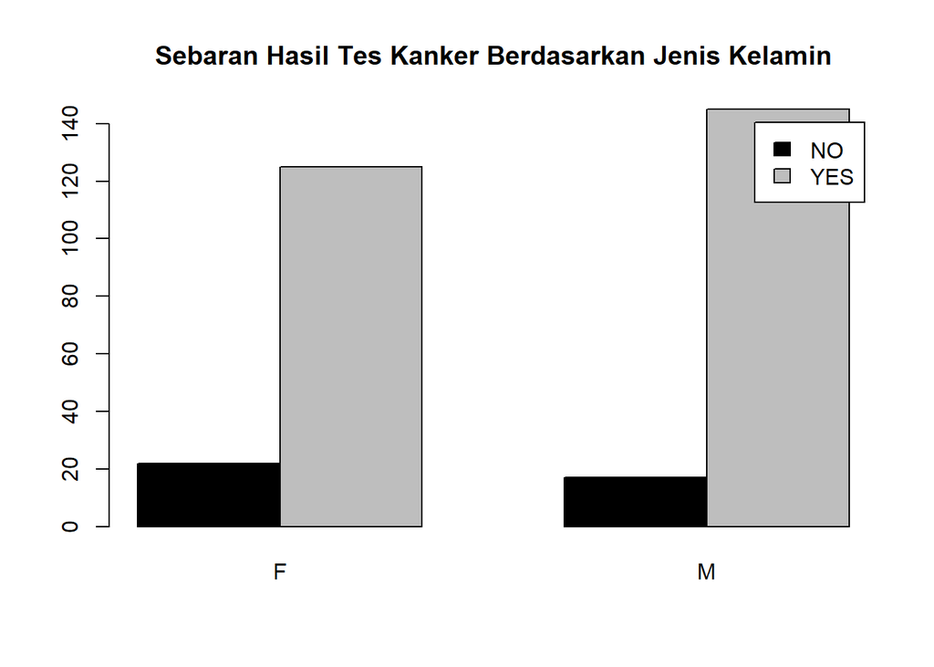

```r
counts = table(data$LUNG_CANCER,data$GENDER)
barplot(counts, main="Sebaran Hasil Tes Kanker Berdasarkan Jenis Kelamin",
        xlab=" ", col=c("black","grey"),legend=rownames(counts), beside=TRUE)
```

Histogram menunjukkan bahwa pada jenis kelamin tertentu (pria atau wanita), kategori “Yes” (kemungkinan hasil tes positif) memiliki jumlah yang lebih banyak daripada kategori “No” (kemungkinan hasil tes negatif).

# Analisis Regresi Logistik

```r
model = glm(Y ~ X1+X2+X3+X4+X5+X6+X7, data = data, family = binomial)
summary(model)
```

```
##
## Call:
## glm(formula = Y ~ X1 + X2 + X3 + X4 + X5 + X6 + X7, family = binomial,
##     data = data)
##
## Coefficients:
##             Estimate Std. Error z value Pr(>|z|)
## (Intercept) -2.44641    1.53995  -1.589 0.112145
## X1M         -0.96967    0.49056  -1.977 0.048079 *
## X2           0.02779    0.02336   1.190 0.234212
## X32          1.10066    0.45464   2.421 0.015481 *
## X42          1.97171    0.53225   3.704 0.000212 ***
## X52          1.69577    0.47465   3.573 0.000353 ***
## X62          2.41018    0.56028   4.302 1.69e-05 ***
## X72          0.78831    0.47390   1.663 0.096224 .
## ---
## Signif. codes:  0 '***' 0.001 '**' 0.01 '*' 0.05 '.' 0.1 ' ' 1
##
## (Dispersion parameter for binomial family taken to be 1)
##
##     Null deviance: 234.30  on 308  degrees of freedom
## Residual deviance: 157.25  on 301  degrees of freedom
## AIC: 173.25
##
## Number of Fisher Scoring iterations: 6
```

```r
beta = coef(model)
OR = exp(beta)
SK = exp(confint(model))
cbind(beta, OR, SK)
```

```
##                    beta          OR       2.5 %     97.5 %
## (Intercept) -2.44641036  0.08660391 0.003802901  1.7209923
## X1M         -0.96967193  0.37920742 0.140046689  0.9704801
## X2           0.02779245  1.02818226 0.982480914  1.0780601
## X32          1.10066043  3.00615073 1.264684989  7.6234791
## X42          1.97170560  7.18291720 2.658621777 21.8870535
## X52          1.69577019  5.45084255 2.211022659 14.4065883
## X62          2.41018064 11.13597258 4.066173708 37.7842280
## X72          0.78831024  2.19967635 0.880374750  5.7280566
```

# Hasil Varians Inflasi Faktor (VIF)

```r
vif(model)
```

```
##       X1       X2       X3       X4       X5       X6       X7
## 1.422645 1.052037 1.232859 1.263148 1.224943 1.125771 1.252044
```

# Interpretasi:

#### Koefisien Model:

- Intercept menunjukkan nilai log odds ketika semua prediktor adalah nol.
- Koefisien negatif pada X1M menunjukkan bahwa pria (X1M = 1) memiliki log odds yang lebih rendah daripada wanita (X1M = 0) dalam pengembangan kanker paru-paru.
- Koefisien positif pada variabel lain menunjukkan peningkatan log odds untuk kategori tertentu dari variabel tersebut.

#### Signifikansi Statistik:

- Pada tingkat signifikansi 0.05, X1M, X32, X42, X52, dan X62 terlihat signifikan.

#### Varians Inflasi Faktor (VIF):

- Semua VIF kurang dari 5, yang menunjukkan tidak ada masalah multicollinearity yang signifikan.

#### Model Fit:

- Deviance yang lebih rendah dan AIC yang lebih kecil menunjukkan bahwa model ini mungkin memiliki kesesuaian yang baik dengan data.

#### Odds Ratio (OR):

- OR mengukur perubahan dalam odds kategori tertentu dibandingkan dengan referensi. Sebagai contoh, OR untuk X1M adalah sekitar 0.379, yang berarti pria memiliki odds 0.379 kali dari wanita dalam pengembangan kanker paru-paru.